# Praktikum Rechnernetze

### 1.3.4 Experimentieren Sie mit nachfolgenden Befehlen nach Aufruf einer beliebigen Website und dokumentieren Sie Ihre Ergebnisse

Als Erstes wurde unser Router von unserem Lokalen Computer angepingt.

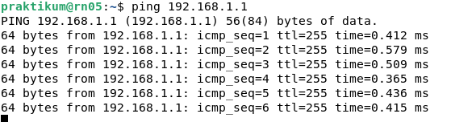

Ping an unseren Router

Danach wurde der Router im Rechnernetze-Labor von unserem Router angepingt.

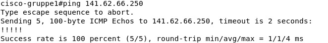

Ping an Router im Rechnernetze-Labor

Danach haben wir den Google DNS-Server angepingt.

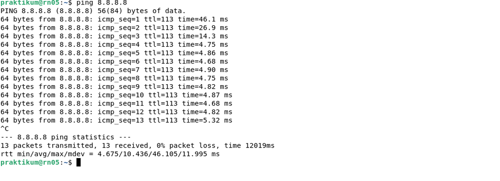

Ping an den Google DNS-Server

Von den folgenden Kommandos haben wir vergessen Screenshots zu machen, daher finden sich im Folgenden Bilder aus dem Internet, die die Funktionalität der Kommandos illustrieren sollen. Die Konfiguration unterscheidet sich offensichtlich.

`show ip nat statistics`

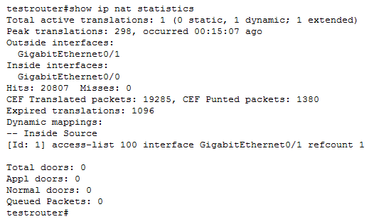

http://blog.soundtraining.net/2013/02/nat-configuration-on-cisco-router-port.html

`show ip nat translation`

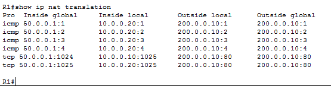

https://www.computernetworkingnotes.com/ccna-study-guide/configure-pat-in-cisco-router-with-examples.html

`debug ip nat`

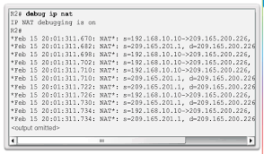

https://www.google.com/search?q=debug+ip+nat&rlz=1C5CHFA_enDE964DE964&source=lnms&tbm=isch&sa=X&ved=2ahUKEwibntq-84D0AhWE2KQKHWMIBfIQ_AUoAXoECAEQAw&biw=1622&bih=857&dpr=2#imgrc=40zndQOWKiYsiM&imgdii=t1e4jXoag0v3iM

## 1.4 Internet-Verbindung ohne NAT

### 1.4.1 Konfigurieren Sie Ihren Router ohne NAT so, dass vom Subnetz ihrer Wahl eine Internet-Verbindung moeglich ist. Richten Sie dabei jeweils zwei Subnetze ein und stellen Sie zusaetzlich sicher, dass beide Subnetze sich gegenseitig erreichen koennen.

Nach einem Reset des NVRAMs & einem `reload` wurden zwei IP-Addressen und die korrespondierenden Subnetzmasken für die Subnetze zugeordnet:

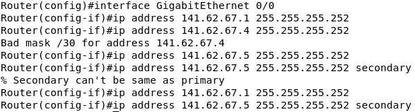

Einrichtung beider IP-Addressen

Mittels `ip route 141.62.67.1 0.0.0.0 141.62.66.250` wurde nun vom 1. Subnetz eine Internetverbindung über den Laborrouter aufgebaut. Mittels `ping` wurde hier nochmal gechecked, ob dieser auch zu erreichen ist:

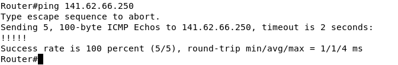

Check der Erreichbarkeit des Laborrouters

Aufgrund von Zeitmangel konnte leider keine weitere Konfiguration vorgenommen werden. Die nächsten Schritt wären gewesen:

1. Einrichten von IP-Addressen und Subnetzmasken auf der Workstation für die beiden Subnetze (`ip addr add` etc.) hinter beiden Routern
2. Test, ob aus dem 1. Subnetz eine Internetverbindung möglich ist (i.e. mittels `ping 8.8.8.8`)
3. Test, ob die Subnetze erreichbar sind, z.B. indem eine IP aus Subnetz 1 der Nachbargruppe mittels unserer Workstation ange`ping`t wird

### 1.4.2 Dokumentieren Sie die Konfiguration und auch die Routing-Tabelle des Routers und des PCs

Leider hat es hierzu aufgrund von Zeitmangel nicht mehr gereicht.